# 02_landscape_complexity

Arthur de Grandpré

24 février 2020

# 2. how to quantify landscape complexity

```
##           used (Mb) gc trigger (Mb) max used (Mb)
## Ncells  539238 28.8    1229847 65.7   621665 33.3
## Vcells 1014076  7.8    8388608 64.0  1601614 12.3
```

## 2.1. Landscape visualisation & classification tools

```r
scape_noise = raster("../results/simulated_scapes/scape_noise.tif")
scape_clean = raster("../results/simulated_scapes/scape_clean.tif")
```

### 2.3.1. Pixel based

### 2.3.1.1. unsupervised

### 2.3.1.1.1 landscapetools

landscapetools brings raster visualisation and manipulation tools to work fast with simulated (or real) landscapes.  
it can be used to rescale, binarize, classify and visualize rasters.

let’s binarize our simulated landscapes and compare the noisy and clean ones with different binarization tresholds.

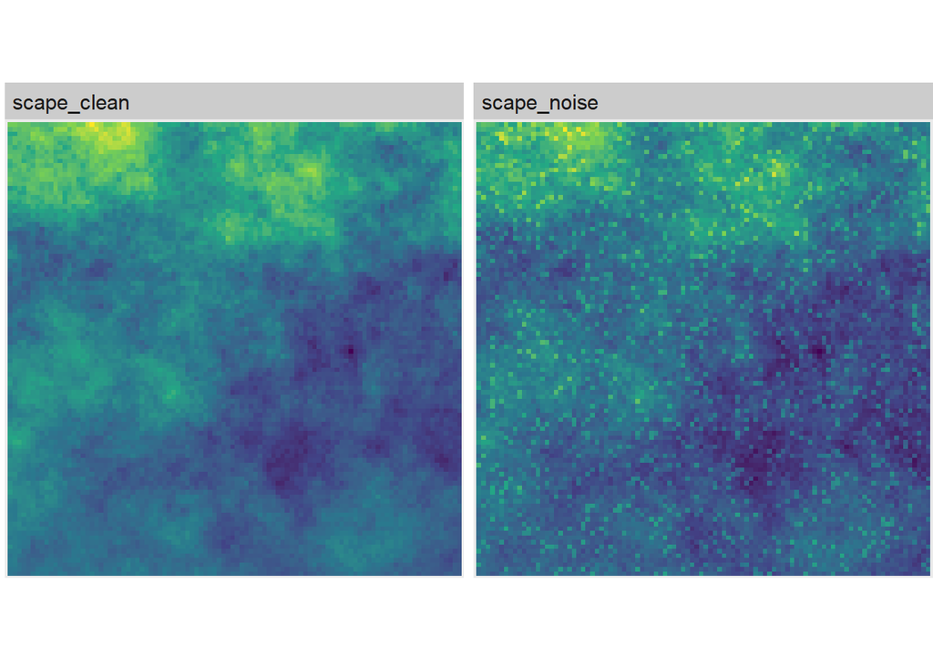

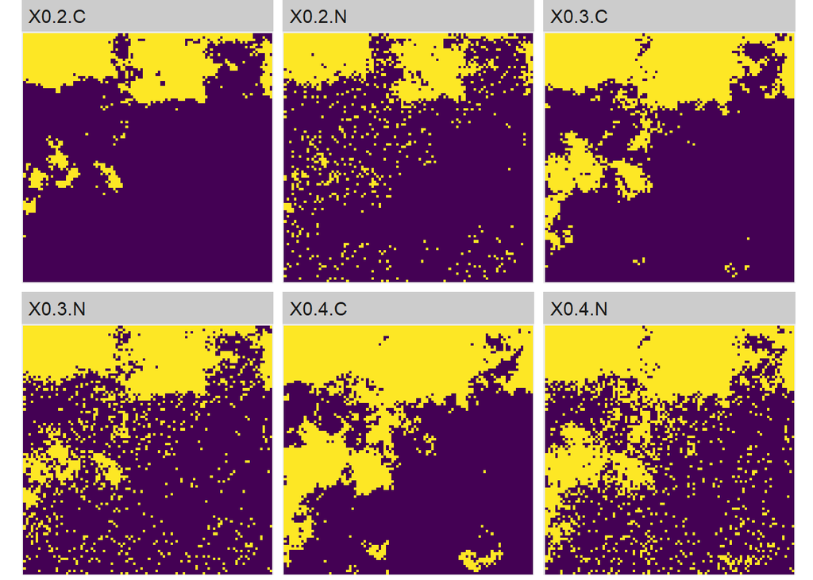

Noisy images tend to have very grainy classification, with large amounts of stray pixels.  
Let’s classify the same landscapes with different numbers of classes, from 2 to 4, using the default algorythm

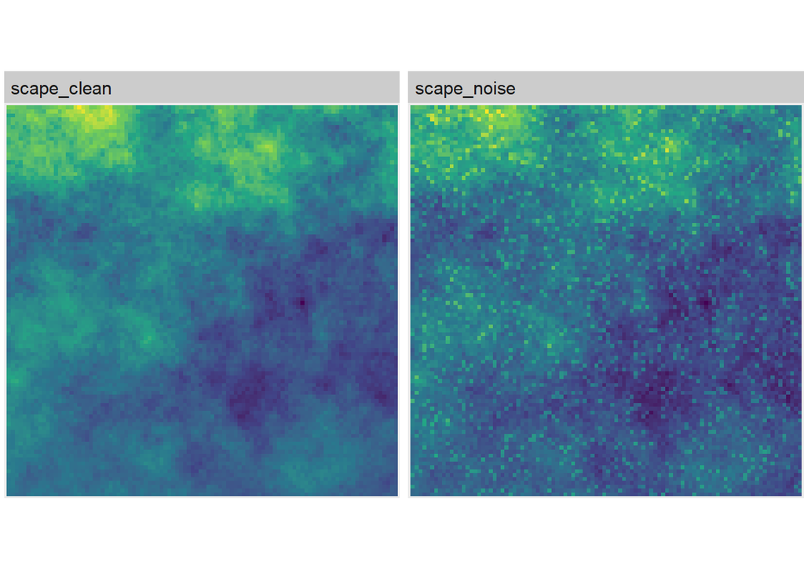

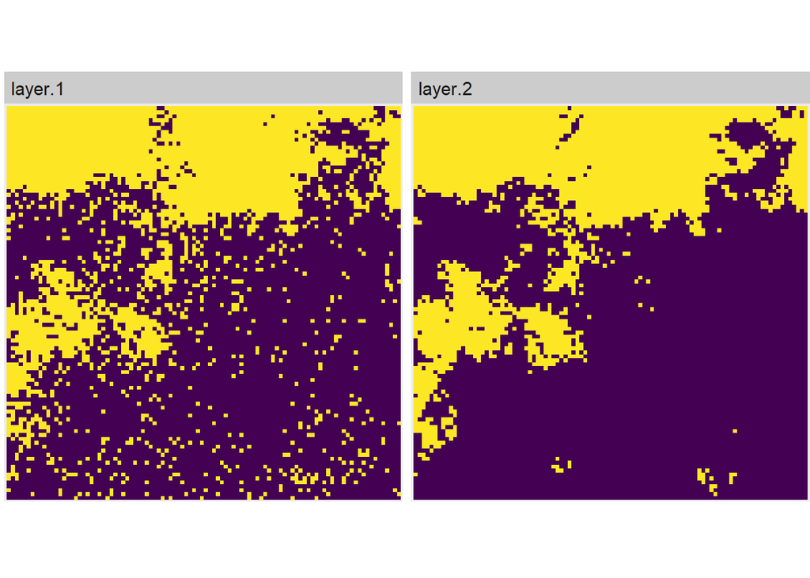

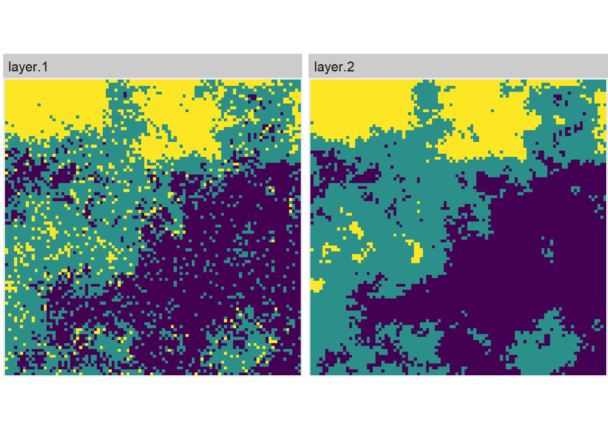

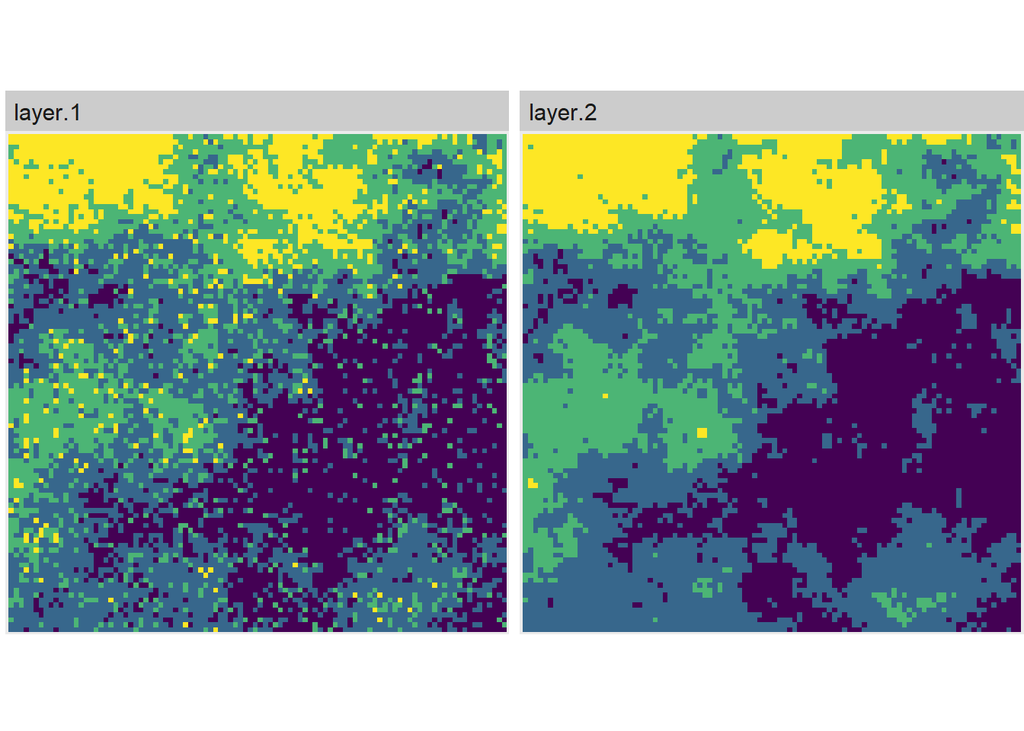

We can also set the proportion of the image taken by every classes

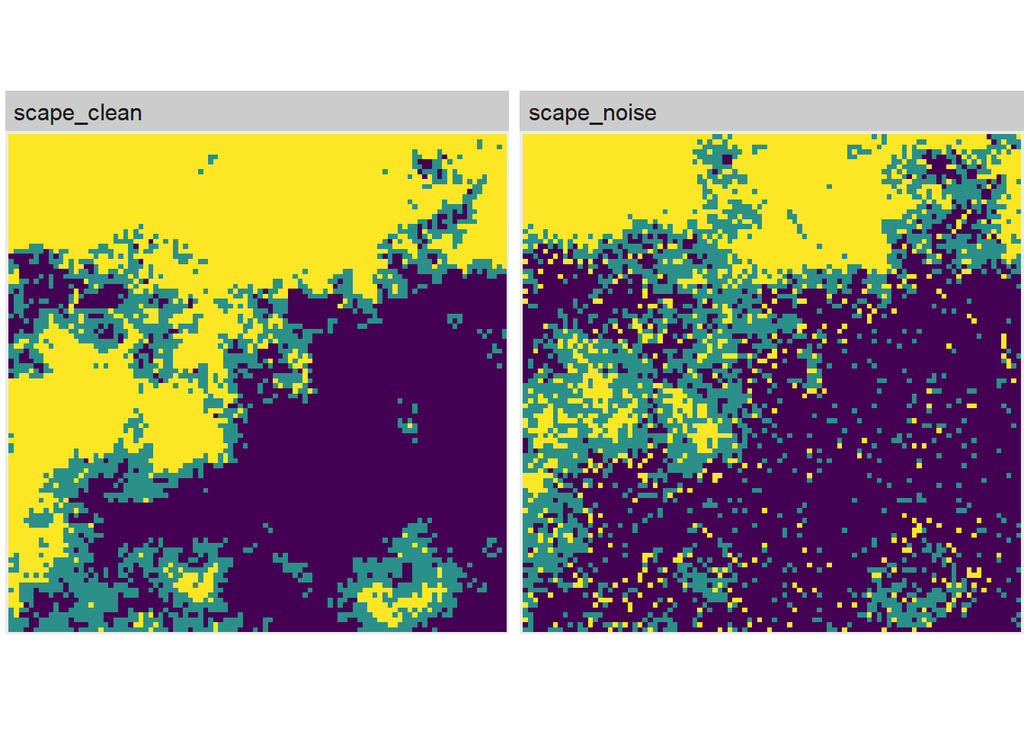

Clearly, noisy pixels are expected to greatly affect complexity measurements within this type of landscape. Object based methods might be able to buffer this effect.

### 2.3.1.1. supervised (?)

### 2.3.2. Object based

### 2.3.2.1 Orfeo Toolbox

Orfeo Toolbox is an open-source toolbox for high resolution remote sensing image analysis. It is one of the rare free software suite to offer multiband image segmentation tools and feature extraction tools. It can be launched from its own GUI (Monteverdi), from a QGIS plugin, from the command line or called in it’s command line form using R, python, etc.

### 2.3.2.1.1 Image segmentation

Firt, we need to define a function to call orfeo directly from R. This is going to call the meanshift segmentation tool.

```r
meanshift.segm <- function(otb.path  = "",
                           raster.in = "",
                           out.path  = "",
                           name      = "",
                           filter.meanshift.spatialr = "5",   #default 5
                           filter.meanshift.ranger   = "0.003",  #default 15
                           filter.meanshift.thres    = "0.001", #default 0.1
                           filter.meanshift.maxiter  = "100", #default 100
                           filter.meanshift.minsize  = "10"  #default 100

                           ){

# Set configuration
conf <- paste("-RAM 4096","-in",raster.in,"-filter meanshift","-filter.meanshift.spatialr",filter.meanshift.spatialr,
                "-filter.meanshift.ranger",filter.meanshift.ranger,"-filter.meanshift.thres",filter.meanshift.thres,
                "-filter.meanshift.maxiter",filter.meanshift.maxiter,"-filter.meanshift.minsize",filter.meanshift.minsize,
                "-mode vector","-mode.vector.out",paste0(out.path,"/",name,".shp"))

  shell(paste("pushd ",otb.path,"&& otbcli_Segmentation ",conf))

write.table(x = conf,file = paste(out.path,"/",name,"_conf.txt",sep=""),row.names = F, col.names = F)
}
```

We can then use function to perform a segmentation onto our desired scene(s).

```r
input_dir = dir(paste0("C:\\Users\\Arthur\\Desktop\\Rscripts\\roxe\\scale_resolution_complexity\\results\\simulated_scapes"),full.names=T, pattern=".tif$")

output_dir = "C:\\Users\\Arthur\\Desktop\\Rscripts\\roxe\\scale_resolution_complexity\\results\\simulated_scapes\\seg"

 for(i in 1:length(input_dir)){

meanshift.segm(filter.meanshift.spatialr = "5",   #default 5
               filter.meanshift.ranger   = "0.003",  #default 15
               filter.meanshift.thres    = "0.01", #default 0.1
               filter.meanshift.maxiter  = "100", #default 100
               filter.meanshift.minsize  = "10",  #default 100
               otb.path  = "D:\\OTB-7.0.0-Win64\\bin",
               raster.in = gsub("/","\\\\",input_dir[i]),
               out.path  = gsub("/","\\\\",output_dir),
               name      = str_sub(input_dir[i],-15))

 }
```

segments should be slightly different in both images, because of the added noise.

```r
shp = dir("../results/simulated_scapes/seg",pattern=".shp$",full.names=T)
cs = readOGR(shp[1])
ns = readOGR(shp[2])
```

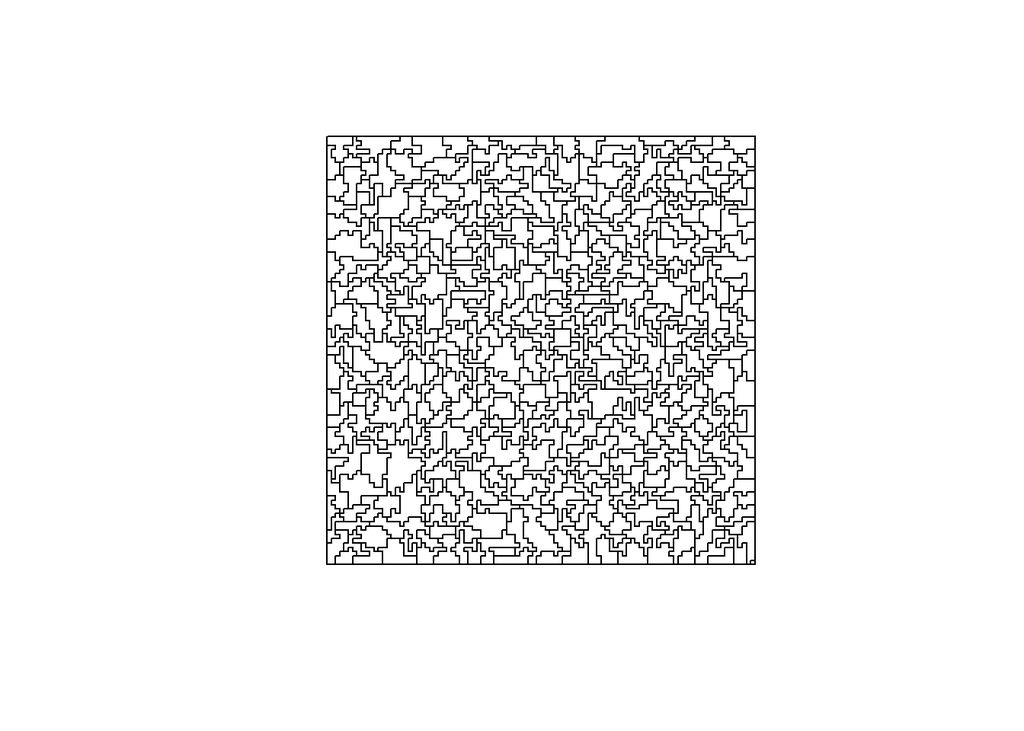

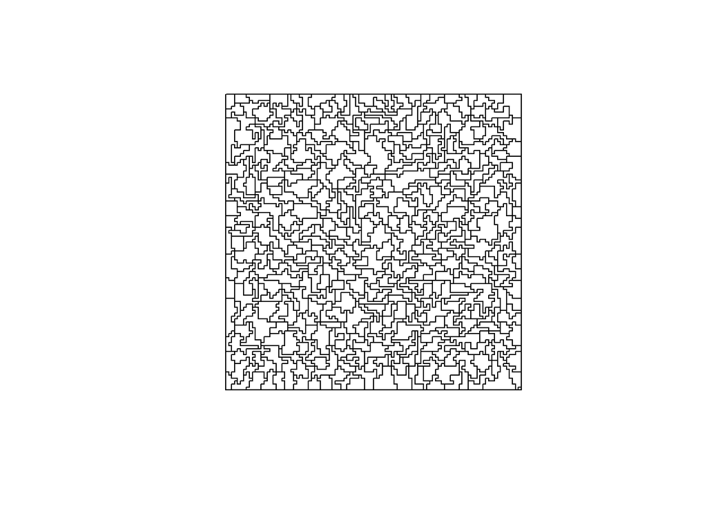

```r
plot(cs);plot(ns)
```

Now, different values can be extracted from the polygons, such as zonal statistics and “features”  
Let’s just compare how both images react to a mean = 0.5 object treshold

```
## [1] "scape 1 of 2"
```

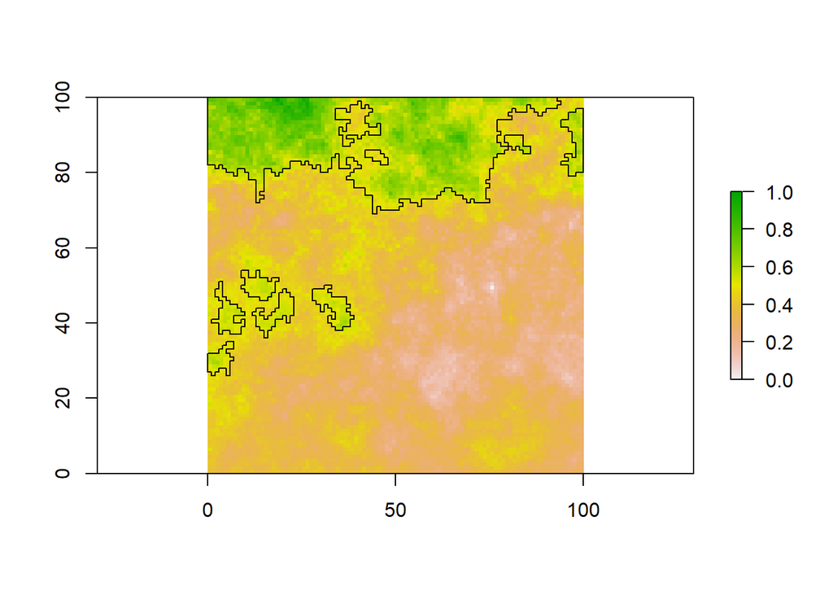

```
## [1] "scape 2 of 2"
```

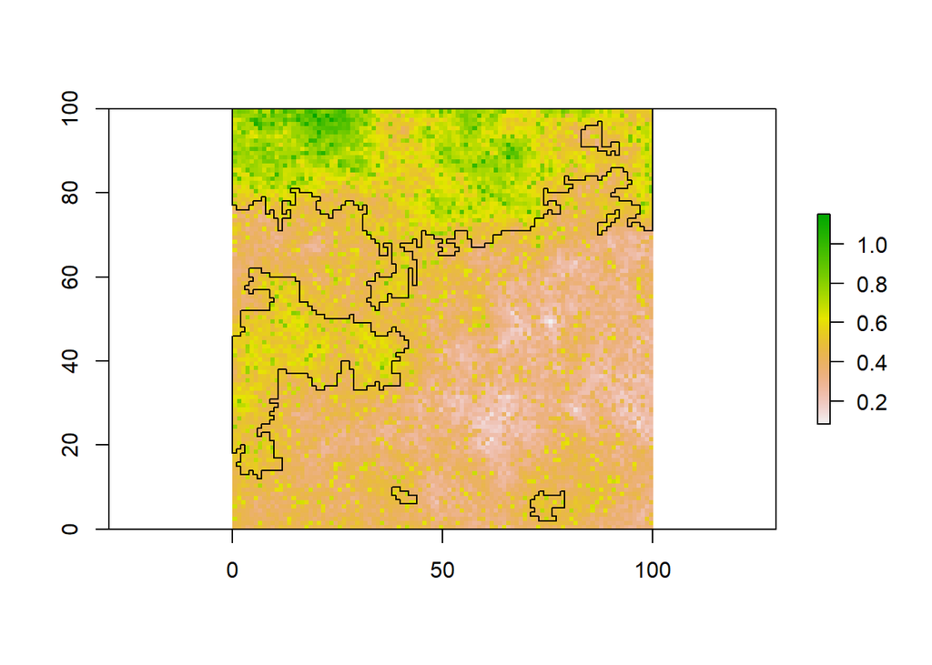

```r
 for(i in 1:length(input_dir)){
print(paste0("scape ",i," of ",length(input_dir)))

r = brick(input_dir[i])
rv = velox::velox(r)

# adding vegetation indexes
psp = readOGR(shp[i])

extract = as.data.frame(rv$extract(psp, fun=mean))

psp@data = cbind(psp@data,extract)

treshold = 0.5
mask = psp[psp@data$V1>treshold,]
mask2 = st_as_sf(mask)
masku = st_union(mask2)

plot(r)
plot(masku,add=T)
}
```

We can see that the addition of noise can have a major impact on segmentation and classification results, with the appearance of many “false positives” in single feature classification. Use of multiple features classification could make this approach more robust.

### 2.3.2.1.2 Feature extraction

# 3. simulating landscapes of different complexity scales at different resolution

# 4. natural scale gradient of spatial complexity